# Perceptron algorithm

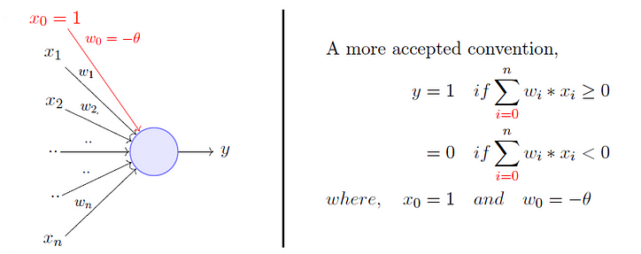

A single perceptron can only be used to implement linearly separable functions. It takes both real and boolean inputs and associates a set of weights to them, along with a bias.

The key intuition behind the perceptron is that it learns to classify simple patterns. If trained correctly, it can learn to distinguish between two classes based on the weighting of the inputs. However, the limitation is that a single perceptron cannot learn more complex patterns or perform more sophisticated tasks.

# Pseudocode

Step 1: Initialize the perceptron

To start, we need to initialize our perceptron with random weights and a learning rate. The learning rate determines how much we adjust the weights during learning.

Step 2: Define the activation function

Step 3: Train the perceptron

To train the perceptron, we feed it training data.

Training data consists of input-output pairs, which are examples of what we want the perceptron to learn to predict.

For each training example:

Calculate the weighted sum of the inputs. Apply the activation function to the weighted sum. Calculate the error between the predicted output and the desired output. Adjust the weights of the perceptron based on the error. We repeat this process for all training examples until the perceptron learns to predict the desired output with sufficient accuracy.

Step 4: Use the trained perceptron to make predictions

Once the perceptron is trained, we can use it to make predictions on new data. To do this, we simply feed the perceptron new data and calculate the predicted output.

# implementation

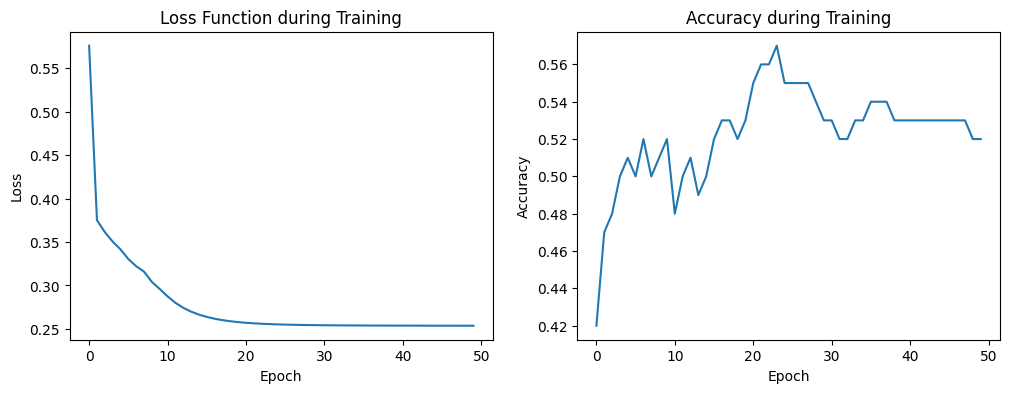

[output not shown]

```python
# Import necessary libraries
import tensorflow as tf
import numpy as np
import matplotlib.pyplot as plt

# Define the VacationPlanner class, a simple perceptron for vacation planning
class VacationPlanner(tf.Module):
    def __init__(self, input_size, learning_rate=0.01):
        # Initialize weights and bias with random values
        self.weights = tf.Variable(tf.random.normal([input_size]))
        self.bias = tf.Variable(tf.random.normal([1]))
        self.learning_rate = learning_rate
        # Use Stochastic Gradient Descent (SGD) as the optimizer
        self.optimizer = tf.optimizers.SGD(learning_rate=self.learning_rate)
        # Lists to store the loss and accuracy history during training
        self.loss_history = []
        self.accuracy_history = []

    # Rectified Linear Unit (ReLU) activation function
    def relu(self, x):
        return tf.maximum(0., x)

    # Perceptron prediction function
    def predict(self, inputs):
        weighted_sum = tf.reduce_sum(tf.multiply(inputs, self.weights)) + self.bias
        activation = self.relu(weighted_sum)
        return activation

    # Mean Squared Error (MSE) loss function
    def compute_loss(self, predictions, targets):
        loss = tf.reduce_mean(tf.square(predictions - targets))
        return loss

    # Accuracy calculation function
    def compute_accuracy(self, predictions, targets):
        predictions_binary = tf.cast(predictions > 0.5, tf.float32)
        accuracy = tf.reduce_mean(tf.cast(tf.equal(predictions_binary, targets), tf.float32))
        return accuracy

    # Training step for one example
    def train_step(self, inputs, targets):
        with tf.GradientTape() as tape:
            predictions = self.predict(inputs)
            loss = self.compute_loss(predictions, targets)
            accuracy = self.compute_accuracy(predictions, targets)
        gradients = tape.gradient(loss, [self.weights, self.bias])
        self.optimizer.apply_gradients(zip(gradients, [self.weights, self.bias]))
        return loss, accuracy

    # Training function for the perceptron
    def train(self, inputs, targets, epochs):
        for epoch in range(epochs):
            epoch_loss = 0.0
            epoch_accuracy = 0.0
            for i in range(len(inputs)):
                # Train the model for each example in the dataset
                loss, accuracy = self.train_step(inputs[i:i+1], targets[i:i+1])
                epoch_loss += loss
                epoch_accuracy += accuracy
            # Calculate average loss and accuracy for the epoch
            epoch_loss /= len(inputs)
            epoch_accuracy /= len(inputs)
            # Store the loss and accuracy for visualization
            self.loss_history.append(epoch_loss)
            self.accuracy_history.append(epoch_accuracy)
            # Print the progress during training
            print(f"Epoch {epoch+1}/{epochs}, Loss: {epoch_loss:.4f}, Accuracy: {epoch_accuracy:.4f}")

if __name__ == "__main__":
    # Hyperparameter configuration
    input_size = 4  # Number of input features (e.g., popularity, distance, budget, preference)
    learning_rate = 0.01
    epochs = 50

    # Generate training data for vacation planning
    np.random.seed(42)  # For reproducibility
    num_examples = 100
    vacation_inputs = np.random.rand(num_examples, input_size)

    # Assign meanings to features (e.g., popularity, distance, budget, preference)
    vacation_inputs[:, 0] = vacation_inputs[:, 0] * 0.8 + 0.2  # Popularity between 0.2 and 1
    vacation_inputs[:, 1] = vacation_inputs[:, 1] * 0.8 + 0.2  # Distance between 0.2 and 1
    vacation_inputs[:, 2] = vacation_inputs[:, 2] * 0.9 + 0.1  # Budget between 0.1 and 1
    vacation_inputs[:, 3] = vacation_inputs[:, 3] * 0.8 + 0.2  # Preference between 0.2 and 1

    vacation_targets = np.random.randint(2, size=num_examples)  # Vacation or not (0 or 1)

    # Convert data to TensorFlow tensors
    vacation_inputs = tf.constant(vacation_inputs, dtype=tf.float32)
    vacation_targets = tf.constant(vacation_targets, dtype=tf.float32)

    # Initialize the VacationPlanner
    vacation_planner = VacationPlanner(input_size, learning_rate)

    # Train the perceptron
    vacation_planner.train(vacation_inputs, vacation_targets, epochs)

    # Plot the loss function and accuracy during training
    plt.figure(figsize=(12, 4))
    plt.subplot(1, 2, 1)
    plt.plot(vacation_planner.loss_history)
    plt.title('Loss Function during Training')
    plt.xlabel('Epoch')
    plt.ylabel('Loss')

    plt.subplot(1, 2, 2)
    plt.plot(vacation_planner.accuracy_history)
    plt.title('Accuracy during Training')
    plt.xlabel('Epoch')
    plt.ylabel('Accuracy')

    plt.show()

    # Example prediction after training
    new_vacation = tf.constant([0.7, 0.4, 0.8, 0.6], dtype=tf.float32)
    prediction = vacation_planner.predict(new_vacation)

    print("Should i plan vacations?", "Yes" if prediction.numpy() > 0.5 else "No")
```

```
Dataset:
    Popularity  Distance    Budget  Preference  Plan Vacation
0     0.499632  0.960571  0.758795    0.678927            0.0
1     0.324815  0.324796  0.152275    0.892941            1.0
2     0.680892  0.766458  0.118526    0.975928            0.0
3     0.865954  0.369871  0.263642    0.346724            0.0
4     0.443394  0.619805  0.488751    0.432983            1.0
..         ...       ...       ...         ...            ...
95    0.294532  0.757390  0.666049    0.901978            1.0
96    0.788057  0.842785  0.353831    0.341952            1.0
97    0.800492  0.845468  0.991455    0.530094            1.0
98    0.497614  0.821130  0.406723    0.944606            0.0
99    0.886730  0.543195  0.775784    0.803634            0.0

[100 rows x 5 columns]
```

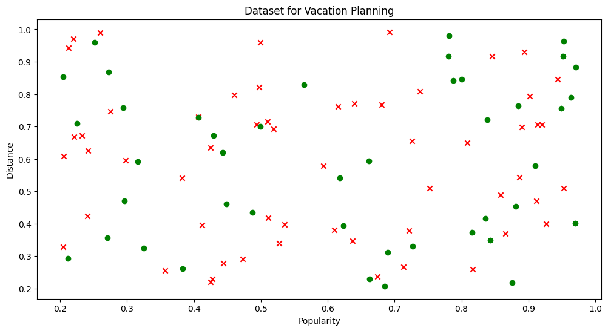

```python
import pandas as pd
data_dict = {
    'Popularity': vacation_inputs[:, 0],
    'Distance': vacation_inputs[:, 1],
    'Budget': vacation_inputs[:, 2],
    'Preference': vacation_inputs[:, 3],
    'Plan Vacation': vacation_targets
}

df = pd.DataFrame(data_dict)

print("Dataset:")
print(df)

plt.figure(figsize=(12, 6))

for i in range(df.shape[0]):
    if df['Plan Vacation'][i] == 1:
        plt.scatter(df['Popularity'][i], df['Distance'][i], color='green', marker='o', label='Plan Vacation')
    else:
        plt.scatter(df['Popularity'][i], df['Distance'][i], color='red', marker='x', label='Do Not Plan Vacation')

plt.title('Dataset for Vacation Planning')
plt.xlabel('Popularity')
plt.ylabel('Distance')
plt.show()
```

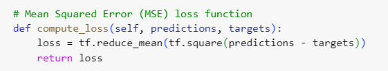

loss function implementation

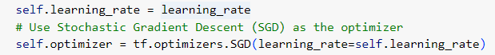

Optimization function